# Uniones de Transformacion

Ditz Yanina

2022-06-09

# 1 Repaso

Una clave primaria identifica únicamente una observación en su propia tabla. Una clave foránea únicamente identifica una observación en otra tabla. Una forma de verificar cuando una clave es primaria es usando count() con las claves primarias y buscar las entradas con n mayor a uno. De esta manera se verifica la forma única de observación:

```
## # A tibble: 336,776 x 19
##     anio   mes   dia horario_salida salida_programada atraso_salida
##    <int> <int> <int>          <int>             <int>         <dbl>
##  1  2013     1     1            517               515             2
##  2  2013     1     1            533               529             4
##  3  2013     1     1            542               540             2
##  4  2013     1     1            544               545            -1
##  5  2013     1     1            554               600            -6
##  6  2013     1     1            554               558            -4
##  7  2013     1     1            555               600            -5
##  8  2013     1     1            557               600            -3
##  9  2013     1     1            557               600            -3
## 10  2013     1     1            558               600            -2
## # ... with 336,766 more rows, and 13 more variables: horario_llegada <int>,
## #   llegada_programada <int>, atraso_llegada <dbl>, aerolinea <chr>,
## #   vuelo <int>, codigo_cola <chr>, origen <chr>, destino <chr>,
## #   tiempo_vuelo <dbl>, distancia <dbl>, hora <dbl>, minuto <dbl>,
## #   fecha_hora <dttm>
```

```
## # A tibble: 3,322 x 9
##    codigo_cola  anio tipo           fabricante modelo motores asientos velocidad
##    <chr>       <int> <chr>          <chr>      <chr>    <int>    <int>     <int>
##  1 N10156       2004 Ala fija mult~ EMBRAER    EMB-1~       2       55        NA
##  2 N102UW       1998 Ala fija mult~ AIRBUS IN~ A320-~       2      182        NA
##  3 N103US       1999 Ala fija mult~ AIRBUS IN~ A320-~       2      182        NA
##  4 N104UW       1999 Ala fija mult~ AIRBUS IN~ A320-~       2      182        NA
##  5 N10575       2002 Ala fija mult~ EMBRAER    EMB-1~       2       55        NA
##  6 N105UW       1999 Ala fija mult~ AIRBUS IN~ A320-~       2      182        NA
##  7 N107US       1999 Ala fija mult~ AIRBUS IN~ A320-~       2      182        NA
##  8 N108UW       1999 Ala fija mult~ AIRBUS IN~ A320-~       2      182        NA
##  9 N109UW       1999 Ala fija mult~ AIRBUS IN~ A320-~       2      182        NA
## 10 N110UW       1999 Ala fija mult~ AIRBUS IN~ A320-~       2      182        NA
## # ... with 3,312 more rows, and 1 more variable: tipo_motor <chr>
```

```
## # A tibble: 16 x 2
##    aerolinea nombre
##    <chr>     <chr>
##  1 9E        Endeavor Air Inc.
##  2 AA        American Airlines Inc.
##  3 AS        Alaska Airlines Inc.
##  4 B6        JetBlue Airways
##  5 DL        Delta Air Lines Inc.
##  6 EV        ExpressJet Airlines Inc.
##  7 F9        Frontier Airlines Inc.
##  8 FL        AirTran Airways Corporation
##  9 HA        Hawaiian Airlines Inc.
## 10 MQ        Envoy Air
## 11 OO        SkyWest Airlines Inc.
## 12 UA        United Air Lines Inc.
## 13 US        US Airways Inc.
## 14 VX        Virgin America
## 15 WN        Southwest Airlines Co.
## 16 YV        Mesa Airlines Inc.
```

```
## # A tibble: 1,458 x 8
##    codigo_aeropuerto nombre  latitud longitud altura zona_horaria horario_verano
##    <chr>             <chr>     <dbl>    <dbl>  <dbl>        <dbl> <chr>
##  1 04G               Lansdo~    41.1    -80.6   1044           -5 A
##  2 06A               Moton ~    32.5    -85.7    264           -6 A
##  3 06C               Schaum~    42.0    -88.1    801           -6 A
##  4 06N               Randal~    41.4    -74.4    523           -5 A
##  5 09J               Jekyll~    31.1    -81.4     11           -5 A
##  6 0A9               Elizab~    36.4    -82.2   1593           -5 A
##  7 0G6               Willia~    41.5    -84.5    730           -5 A
##  8 0G7               Finger~    42.9    -76.8    492           -5 A
##  9 0P2               Shoest~    39.8    -76.6   1000           -5 U
## 10 0S9               Jeffer~    48.1   -123.     108           -8 A
## # ... with 1,448 more rows, and 1 more variable: zona_horaria_iana <chr>
```

```
## # A tibble: 26,115 x 15
##    origen  anio   mes   dia  hora temperatura punto_rocio humedad
##    <chr>  <int> <int> <int> <int>       <dbl>       <dbl>   <dbl>
##  1 EWR     2013     1     1     1        39.0        26.1    59.4
##  2 EWR     2013     1     1     2        39.0        27.0    61.6
##  3 EWR     2013     1     1     3        39.0        28.0    64.4
##  4 EWR     2013     1     1     4        39.9        28.0    62.2
##  5 EWR     2013     1     1     5        39.0        28.0    64.4
##  6 EWR     2013     1     1     6        37.9        28.0    67.2
##  7 EWR     2013     1     1     7        39.0        28.0    64.4
##  8 EWR     2013     1     1     8        39.9        28.0    62.2
##  9 EWR     2013     1     1     9        39.9        28.0    62.2
## 10 EWR     2013     1     1    10        41          28.0    59.6
## # ... with 26,105 more rows, and 7 more variables: direccion_viento <dbl>,
## #   velocidad_viento <dbl>, velocidad_rafaga <dbl>, precipitacion <dbl>,
## #   presion <dbl>, visibilidad <dbl>, fecha_hora <dttm>
```

```
## # A tibble: 0 x 2
## # ... with 2 variables: codigo_cola <chr>, n <int>
```

```
## # A tibble: 3 x 6
##    anio   mes   dia  hora origen     n
##   <int> <int> <int> <int> <chr>  <int>
## 1  2013    11     3     1 EWR        2
## 2  2013    11     3     1 JFK        2
## 3  2013    11     3     1 LGA        2
```

# 2 Uniones de transformación

Una unión de transformación te permite combinar variables a partir de dos tablas. Primero busca coincidencias de observaciones de acuerdo a sus claves y luego copia las variables de una tabla en la otra.

Con select(), seleccionar un subconjunto de vuelos que contenga como variables a las claves foraneas.

```r
vuelos2<- vuelos %>%
 select(anio:dia, hora, origen, destino, codigo_cola, aerolinea)
#View(vuelos)
vuelos2
```

```
## # A tibble: 336,776 x 8
##     anio   mes   dia  hora origen destino codigo_cola aerolinea
##    <int> <int> <int> <dbl> <chr>  <chr>   <chr>       <chr>
##  1  2013     1     1     5 EWR    IAH     N14228      UA
##  2  2013     1     1     5 LGA    IAH     N24211      UA
##  3  2013     1     1     5 JFK    MIA     N619AA      AA
##  4  2013     1     1     5 JFK    BQN     N804JB      B6
##  5  2013     1     1     6 LGA    ATL     N668DN      DL
##  6  2013     1     1     5 EWR    ORD     N39463      UA
##  7  2013     1     1     6 EWR    FLL     N516JB      B6
##  8  2013     1     1     6 LGA    IAD     N829AS      EV
##  9  2013     1     1     6 JFK    MCO     N593JB      B6
## 10  2013     1     1     6 LGA    ORD     N3ALAA      AA
## # ... with 336,766 more rows
```

Imaginemos que se quiere incluir el nombre completo de cada aerolínea en vuelos2. Para ello combinamos los datos de aerolineas y vuelos2 con left_join():

```r
vuelos2 %>%
  select(-origen, -destino) %>%
  left_join(aerolineas, by = "aerolinea")
```

```
## # A tibble: 336,776 x 7
##     anio   mes   dia  hora codigo_cola aerolinea nombre
##    <int> <int> <int> <dbl> <chr>       <chr>     <chr>
##  1  2013     1     1     5 N14228      UA        United Air Lines Inc.
##  2  2013     1     1     5 N24211      UA        United Air Lines Inc.
##  3  2013     1     1     5 N619AA      AA        American Airlines Inc.
##  4  2013     1     1     5 N804JB      B6        JetBlue Airways
##  5  2013     1     1     6 N668DN      DL        Delta Air Lines Inc.
##  6  2013     1     1     5 N39463      UA        United Air Lines Inc.
##  7  2013     1     1     6 N516JB      B6        JetBlue Airways
##  8  2013     1     1     6 N829AS      EV        ExpressJet Airlines Inc.
##  9  2013     1     1     6 N593JB      B6        JetBlue Airways
## 10  2013     1     1     6 N3ALAA      AA        American Airlines Inc.
## # ... with 336,766 more rows
```

Hagamos otro ejemplo:

```r
vuelos2 %>%
  select(-destino, -codigo_cola, -aerolinea) %>%
  left_join(clima, by = c('anio', 'mes', 'dia', 'hora', 'origen'))
```

```
## # A tibble: 336,776 x 15
##     anio   mes   dia  hora origen temperatura punto_rocio humedad
##    <int> <int> <int> <dbl> <chr>        <dbl>       <dbl>   <dbl>
##  1  2013     1     1     5 EWR           39.0        28.0    64.4
##  2  2013     1     1     5 LGA           39.9        25.0    54.8
##  3  2013     1     1     5 JFK           39.0        27.0    61.6
##  4  2013     1     1     5 JFK           39.0        27.0    61.6
##  5  2013     1     1     6 LGA           39.9        25.0    54.8
##  6  2013     1     1     5 EWR           39.0        28.0    64.4
##  7  2013     1     1     6 EWR           37.9        28.0    67.2
##  8  2013     1     1     6 LGA           39.9        25.0    54.8
##  9  2013     1     1     6 JFK           37.9        27.0    64.3
## 10  2013     1     1     6 LGA           39.9        25.0    54.8
## # ... with 336,766 more rows, and 7 more variables: direccion_viento <dbl>,
## #   velocidad_viento <dbl>, velocidad_rafaga <dbl>, precipitacion <dbl>,
## #   presion <dbl>, visibilidad <dbl>, fecha_hora <dttm>
```

En el primer caso, se podría obtener el mismo resultado usando mutate() junto a las operaciones de filtro de R base.

```r
vuelos2 %>%
  select(-origen, -destino) %>%
  mutate(nombre = aerolineas$nombre[match(aerolinea, aerolineas$aerolinea)])
```

```
## # A tibble: 336,776 x 7
##     anio   mes   dia  hora codigo_cola aerolinea nombre
##    <int> <int> <int> <dbl> <chr>       <chr>     <chr>
##  1  2013     1     1     5 N14228      UA        United Air Lines Inc.
##  2  2013     1     1     5 N24211      UA        United Air Lines Inc.
##  3  2013     1     1     5 N619AA      AA        American Airlines Inc.
##  4  2013     1     1     5 N804JB      B6        JetBlue Airways
##  5  2013     1     1     6 N668DN      DL        Delta Air Lines Inc.
##  6  2013     1     1     5 N39463      UA        United Air Lines Inc.
##  7  2013     1     1     6 N516JB      B6        JetBlue Airways
##  8  2013     1     1     6 N829AS      EV        ExpressJet Airlines Inc.
##  9  2013     1     1     6 N593JB      B6        JetBlue Airways
## 10  2013     1     1     6 N3ALAA      AA        American Airlines Inc.
## # ... with 336,766 more rows
```

Vemos que algo simple, pero si sólo se agrega una variable. En otras palabras, cuando se tienen que agregar múltiples variables esto para ser un poco más complicado al momento de enteder lo que se quiere hacer.

## 2.1 Uniones

Consideremos el siguiente ejemplo:

```r
x <- tribble(
  ~key, ~val_x,
  1, "x1",
  2, "x2",
  3, "x3"
)
y <- tribble(
  ~key, ~val_y,
  1, "y1",
  2, "y2",
  4, "y3"
)
```

Para unir filas entre tablas, usaremos las “claves”. En la unión que mostramos, las coincidencias se indican con puntos. El número de puntos es igual al número de coincidencias y al número de filas en la salida.

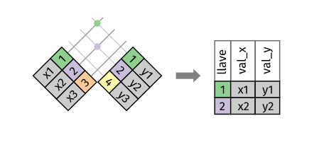

### 2.1.1 Unión interior (intersección)

El output de una unión interior es un nuevo data frame que contiene la clave, los valores de x y los valores de y. Usamos by (según) para indicar a dplyr qué variable es la clave:

```r
x %>%
  inner_join(y, by = "key")
```

```
## # A tibble: 2 x 3
##     key val_x val_y
##   <dbl> <chr> <chr>
## 1     1 x1    y1
## 2     2 x2    y2
```

La propiedad más importante de una unión interior es que las filas no coincidentes no se incluyen en el resultado. Esto significa que generalmente las uniones interiores no son apropiadas para su uso en el análisis de datos dado que es muy fácil perder observaciones.

### 2.1.2 Uniones exteriores

Se tiene 3 tipos de uniones exteriores:

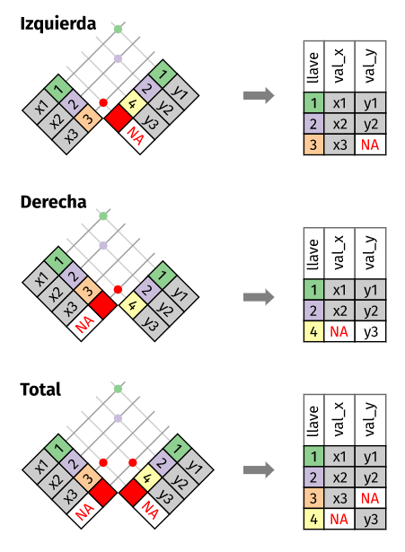

La unión que más frecuentemente se usa es la unión izquierda: úsala cuando necesites buscar datos adicionales en otra tabla, dado que preserva las observaciones originales incluso cuando no hay coincidencias.

### 2.1.3 Claves duplicadas

Hay dos posibilidades:

1. Una tabla tiene claves duplicadas. Esto es útil cuando quieres agregar información adicional dado que típicamente existe una relación uno a muchos.

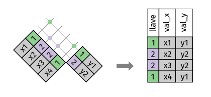

```r
x <- tribble(
 ~key, ~val_x,
 1, "x1",
 2, "x2",
 2, "x3",
 1, "x4"
)
y <- tribble(
 ~key, ~val_y,
 1, "y1",
 2, "y2"
)
duplicadauno<-left_join(x, y, by = "key")
duplicadauno
```

```
## # A tibble: 4 x 3
##     key val_x val_y
##   <dbl> <chr> <chr>
## 1     1 x1    y1
## 2     2 x2    y2
## 3     2 x3    y2
## 4     1 x4    y1
```

2. Ambas tablas tienen claves duplicadas. Esto es usualmente un error debido a que en ninguna de las tablas las claves identifican de manera única una observación.

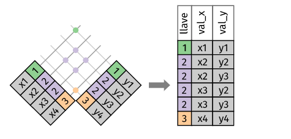

```r
 x <- tribble(
 ~key, ~val_x,
 1, "x1",
 2, "x2",
 2, "x3",
 3, "x4"
  )
  y <- tribble(
 ~key, ~val_y,
 1, "y1",
 2, "y2",
 2, "y3",
 3, "y4"
  )
 duplicada2<- left_join(x, y, by = "key")
 duplicada2
```

```
## # A tibble: 6 x 3
##     key val_x val_y
##   <dbl> <chr> <chr>
## 1     1 x1    y1
## 2     2 x2    y2
## 3     2 x2    y3
## 4     2 x3    y2
## 5     2 x3    y3
## 6     3 x4    y4
```

### 2.1.4 Definiendo las columnas claves

Los pares de tablas siempre se han unido de acuerdo a una única variable y esa variable tiene el mismo nombre en ambas tablas. Esta restricción se expresa de la forma by = “key”.

Por defecto, by = NULL, usa todas las variables que aparecen en ambas tablas, lo que se conoce como unión natural.

```
## # A tibble: 336,776 x 9
##     anio   mes   dia  hora origen destino codigo_cola aerolinea nombre
##    <int> <int> <int> <dbl> <chr>  <chr>   <chr>       <chr>     <chr>
##  1  2013     1     1     5 EWR    IAH     N14228      UA        United Air Line~
##  2  2013     1     1     5 LGA    IAH     N24211      UA        United Air Line~
##  3  2013     1     1     5 JFK    MIA     N619AA      AA        American Airlin~
##  4  2013     1     1     5 JFK    BQN     N804JB      B6        JetBlue Airways
##  5  2013     1     1     6 LGA    ATL     N668DN      DL        Delta Air Lines~
##  6  2013     1     1     5 EWR    ORD     N39463      UA        United Air Line~
##  7  2013     1     1     6 EWR    FLL     N516JB      B6        JetBlue Airways
##  8  2013     1     1     6 LGA    IAD     N829AS      EV        ExpressJet Airl~
##  9  2013     1     1     6 JFK    MCO     N593JB      B6        JetBlue Airways
## 10  2013     1     1     6 LGA    ORD     N3ALAA      AA        American Airlin~
## # ... with 336,766 more rows
```

Un vector de caracteres, by = “x”. Esto es similar a una unión natural, pero usa algunas de las variables comunes. Por ejemplo, vuelos y aviones tienen la variable anio, pero esta significa cosas distintas en cada tabla por lo que queremos unir por codigo_cola.

```
## # A tibble: 336,776 x 16
##    anio.x   mes   dia  hora origen destino codigo_cola aerolinea anio.y tipo
##     <int> <int> <int> <dbl> <chr>  <chr>   <chr>       <chr>      <int> <chr>
##  1   2013     1     1     5 EWR    IAH     N14228      UA          1999 Ala fij~
##  2   2013     1     1     5 LGA    IAH     N24211      UA          1998 Ala fij~
##  3   2013     1     1     5 JFK    MIA     N619AA      AA          1990 Ala fij~
##  4   2013     1     1     5 JFK    BQN     N804JB      B6          2012 Ala fij~
##  5   2013     1     1     6 LGA    ATL     N668DN      DL          1991 Ala fij~
##  6   2013     1     1     5 EWR    ORD     N39463      UA          2012 Ala fij~
##  7   2013     1     1     6 EWR    FLL     N516JB      B6          2000 Ala fij~
##  8   2013     1     1     6 LGA    IAD     N829AS      EV          1998 Ala fij~
##  9   2013     1     1     6 JFK    MCO     N593JB      B6          2004 Ala fij~
## 10   2013     1     1     6 LGA    ORD     N3ALAA      AA            NA <NA>
## # ... with 336,766 more rows, and 6 more variables: fabricante <chr>,
## #   modelo <chr>, motores <int>, asientos <int>, velocidad <int>,
## #   tipo_motor <chr>
```

Un vector de caracteres con nombres: by = c(“a” = “b”). Esto va a unir la variable a en la tabla x con la variabla b en la tabla y. Las variables de x se usarán en el output.

```r
#vuelos2 %>%
 #left_join(aeropuertos, by="codigo_aeropuerto")

#vuelos2 %>%
 # left_join(aeropuertos)

vuelos2 %>%
  left_join(aeropuertos, by=c("origen" = "codigo_aeropuerto"))
```

```
## # A tibble: 336,776 x 15
##     anio   mes   dia  hora origen destino codigo_cola aerolinea nombre   latitud
##    <int> <int> <int> <dbl> <chr>  <chr>   <chr>       <chr>     <chr>      <dbl>
##  1  2013     1     1     5 EWR    IAH     N14228      UA        Newark ~    40.7
##  2  2013     1     1     5 LGA    IAH     N24211      UA        La Guar~    40.8
##  3  2013     1     1     5 JFK    MIA     N619AA      AA        John F ~    40.6
##  4  2013     1     1     5 JFK    BQN     N804JB      B6        John F ~    40.6
##  5  2013     1     1     6 LGA    ATL     N668DN      DL        La Guar~    40.8
##  6  2013     1     1     5 EWR    ORD     N39463      UA        Newark ~    40.7
##  7  2013     1     1     6 EWR    FLL     N516JB      B6        Newark ~    40.7
##  8  2013     1     1     6 LGA    IAD     N829AS      EV        La Guar~    40.8
##  9  2013     1     1     6 JFK    MCO     N593JB      B6        John F ~    40.6
## 10  2013     1     1     6 LGA    ORD     N3ALAA      AA        La Guar~    40.8
## # ... with 336,766 more rows, and 5 more variables: longitud <dbl>,
## #   altura <dbl>, zona_horaria <dbl>, horario_verano <chr>,
## #   zona_horaria_iana <chr>
```

```r
vuelos2 %>%
  left_join(aeropuertos, by=c("destino"="codigo_aeropuerto"))
```

```
## # A tibble: 336,776 x 15
##     anio   mes   dia  hora origen destino codigo_cola aerolinea nombre   latitud
##    <int> <int> <int> <dbl> <chr>  <chr>   <chr>       <chr>     <chr>      <dbl>
##  1  2013     1     1     5 EWR    IAH     N14228      UA        George ~    30.0
##  2  2013     1     1     5 LGA    IAH     N24211      UA        George ~    30.0
##  3  2013     1     1     5 JFK    MIA     N619AA      AA        Miami I~    25.8
##  4  2013     1     1     5 JFK    BQN     N804JB      B6        <NA>        NA
##  5  2013     1     1     6 LGA    ATL     N668DN      DL        Hartsfi~    33.6
##  6  2013     1     1     5 EWR    ORD     N39463      UA        Chicago~    42.0
##  7  2013     1     1     6 EWR    FLL     N516JB      B6        Fort La~    26.1
##  8  2013     1     1     6 LGA    IAD     N829AS      EV        Washing~    38.9
##  9  2013     1     1     6 JFK    MCO     N593JB      B6        Orlando~    28.4
## 10  2013     1     1     6 LGA    ORD     N3ALAA      AA        Chicago~    42.0
## # ... with 336,766 more rows, and 5 more variables: longitud <dbl>,
## #   altura <dbl>, zona_horaria <dbl>, horario_verano <chr>,
## #   zona_horaria_iana <chr>
```

### 2.1.5 Ejercicios

1. Calcula el atraso promedio por destino y luego une los datos en aeropuertos para que puedas mostrar la distribución espacial de los atrasos. Esta es una forma fácil de dibujar un mapa de los Estados Unidos:

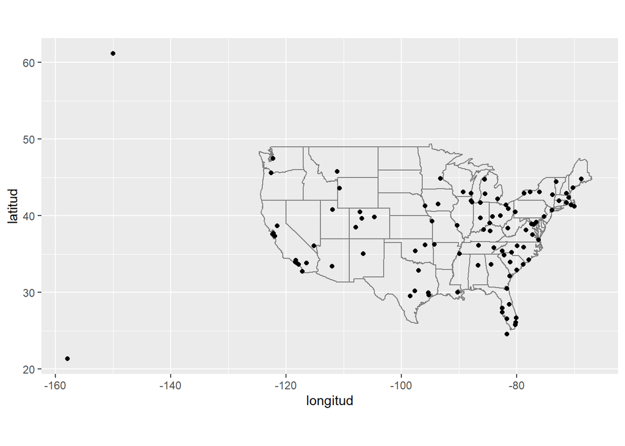

```r
aeropuertos %>%
  semi_join(vuelos, c("codigo_aeropuerto" = "destino")) %>%
  ggplot(aes(longitud, latitud)) +
  borders("state") +
  geom_point() +
  coord_quickmap()
```

Quizás quieras usar size o colour para editar los puntos y mostrar el atraso promedio de cada aeropuerto.

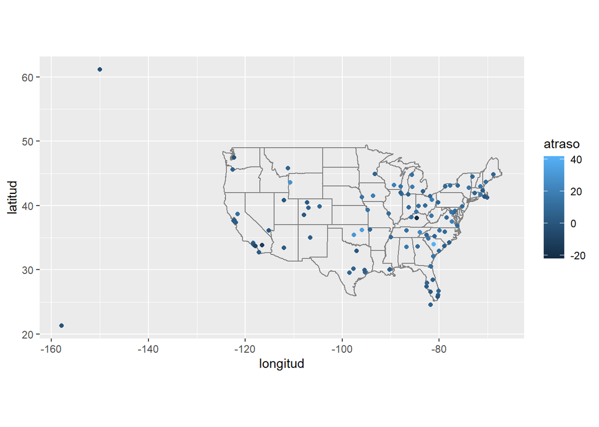

```r
mean_atraso <- vuelos %>%
  group_by(destino) %>%
  summarise(atraso=mean(atraso_llegada, na.rm=TRUE)) %>%
  inner_join(aeropuertos, c(destino="codigo_aeropuerto"))


mean_atraso %>%
  ggplot(aes(longitud, latitud, colour=atraso)) +
  borders("state") +
  geom_point() +
  coord_quickmap()
```

2. Agrega la ubicación de origen y destino (por ejemplo, latitud y longitud) a vuelos.

```r
location_airports<- aeropuertos %>%
  select(codigo_aeropuerto, latitud, longitud)

vuelos %>%
  select(anio, mes, dia, hora, origen, destino) %>%
  left_join(location_airports, c("origen"="codigo_aeropuerto")) %>%
  left_join(location_airports, c("destino"="codigo_aeropuerto"))
```

```
## # A tibble: 336,776 x 10
##     anio   mes   dia  hora origen destino latitud.x longitud.x latitud.y
##    <int> <int> <int> <dbl> <chr>  <chr>       <dbl>      <dbl>     <dbl>
##  1  2013     1     1     5 EWR    IAH          40.7      -74.2      30.0
##  2  2013     1     1     5 LGA    IAH          40.8      -73.9      30.0
##  3  2013     1     1     5 JFK    MIA          40.6      -73.8      25.8
##  4  2013     1     1     5 JFK    BQN          40.6      -73.8      NA
##  5  2013     1     1     6 LGA    ATL          40.8      -73.9      33.6
##  6  2013     1     1     5 EWR    ORD          40.7      -74.2      42.0
##  7  2013     1     1     6 EWR    FLL          40.7      -74.2      26.1
##  8  2013     1     1     6 LGA    IAD          40.8      -73.9      38.9
##  9  2013     1     1     6 JFK    MCO          40.6      -73.8      28.4
## 10  2013     1     1     6 LGA    ORD          40.8      -73.9      42.0
## # ... with 336,766 more rows, and 1 more variable: longitud.y <dbl>
```

3. ¿Existe una relación entre la antiguedad de un avión y sus atrasos?

Depende de los atrasos, si son de llegada o salida. Para poder analizar la antiguedad deberíamos unir los datos de aviones con los vuelos.

```r
aviones2<- select(aviones, codigo_cola, anio_fabricacion=anio)

vuelos %>%
  inner_join(aviones2, by="codigo_cola") %>%
  mutate(antiguedad = anio - anio_fabricacion) %>%
  filter(!is.na(antiguedad)) %>%
  group_by(antiguedad) %>%
  summarise(prom_atraso_llegada=mean(atraso_llegada, na.rm=TRUE),
            prom_atraso_salida=mean(atraso_salida, na.rm=TRUE))
```

```
## # A tibble: 46 x 3
##    antiguedad prom_atraso_llegada prom_atraso_salida
##         <int>               <dbl>              <dbl>
##  1          0                4.01              10.6
##  2          1                2.85               9.64
##  3          2                5.70              11.8
##  4          3                5.18              12.5
##  5          4                4.92              11.0
##  6          5                5.57              13.2
##  7          6                7.54              13.7
##  8          7                9.90              14.6
##  9          8                9.80              14.7
## 10          9               10.2               16.4
## # ... with 36 more rows
```

4. ¿Qué condiciones climáticas hacen más probables los atrasos? Las condiciones climáticas que hacen más probables los atrasos son las tormentas de lluvias fuertes.

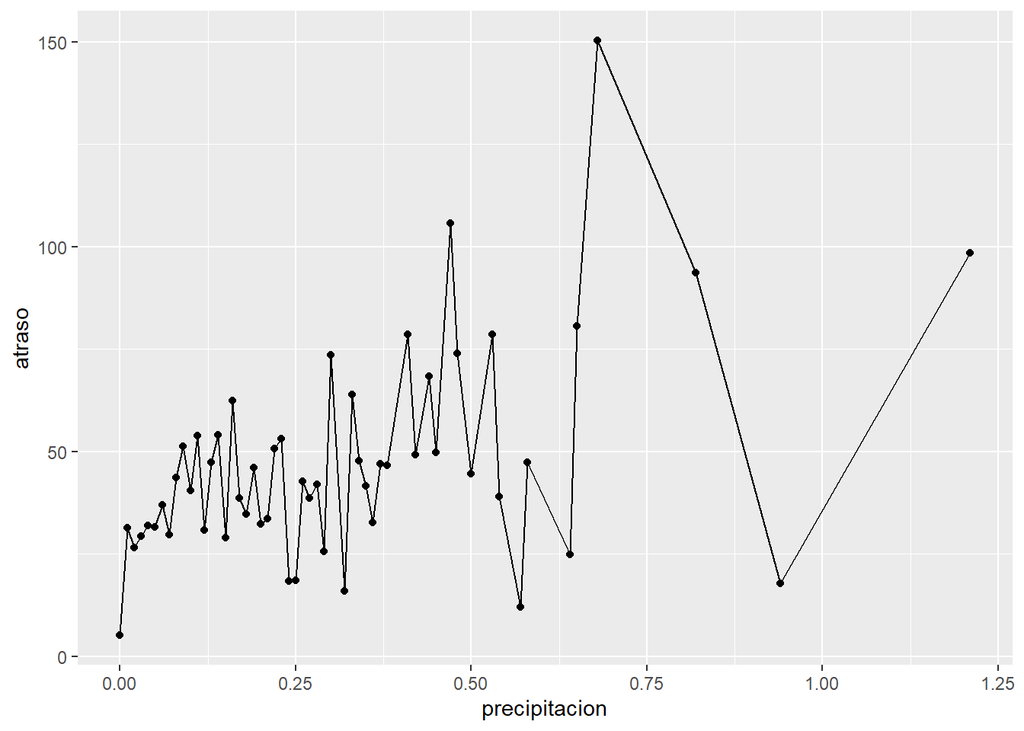

```r
vuelo_clima <- vuelos %>%
  inner_join(clima, by = c(
    "origen",
    "anio",
    "mes",
    "dia",
    "hora"
  ))


vuelo_clima %>%
  group_by(precipitacion) %>%
  summarise(atraso = mean(atraso_llegada, na.rm = TRUE)) %>%
  ggplot(aes(x = precipitacion, y = atraso)) +
  geom_line() +
  geom_point()
```

5. ¿Qué sucedió el día 13 de junio de 2013? Muestra el patrón espacial de los atrasos. Luego, usa un buscador para encontrar referencias cruzadas con el clima.

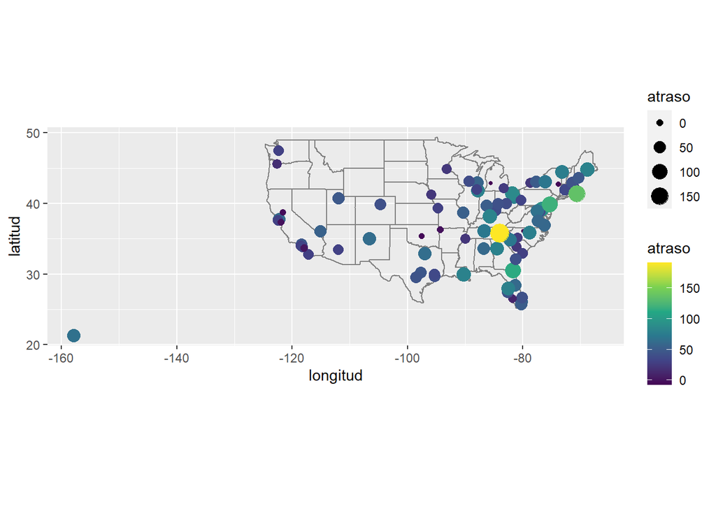

```r
vuelos %>%
  filter(anio == 2013, mes == 6, dia == 13) %>%
  group_by(destino) %>%
  summarise(atraso = mean(atraso_salida, na.rm = TRUE)) %>%
  inner_join(aeropuertos, by = c("destino" = "codigo_aeropuerto")) %>%
  ggplot(aes(y = latitud, x = longitud, size = atraso, colour = atraso)) +
  borders("state") +
  geom_point() +
  coord_quickmap() +
  scale_colour_viridis_c()
```

### 2.1.6 Otras implementaciones

La ventaja de los verbos específicos de dplyr es que muestran de manera clara la intención del código: la diferencia entre las uniones es realmente importante pero se esconde en los argumentos de merge().

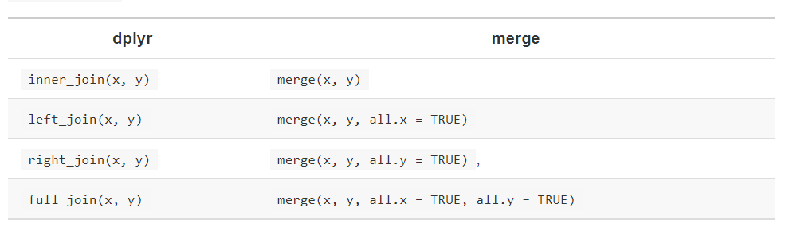

También podemos ver las comparaciones, o similitudes, con SQL:

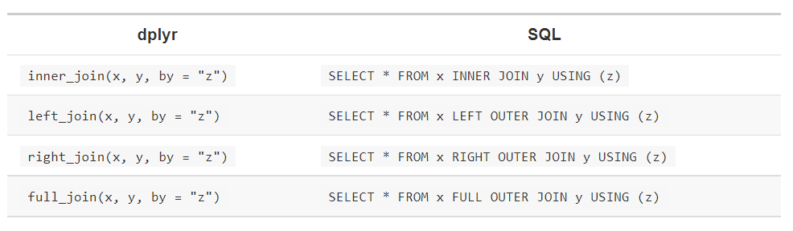

Unir distintas variables entre tablas, por ejemplo inner_join(x, y, by = c(“a” = “b”)), usa una sintaxis ligeramente distinta en SQL: SELECT * FROM x INNER JOIN y ON x.a = y.b. Como la sintaxis sugiere, SQL soporta un rango más amplio de tipos de uniones que dplyr, ya que puedes conectar tablas usando restricciones distintas a las de igualdad.

# 3 Uniones de filtro

Las uniones de filtro unen observaciones de la misma forma que las uniones de transformación pero afectan a las observaciones, no a las variables. Existen dos tipos:

- *semi_join(x, y)* mantiene todas las observaciones en x con coincidencias en y.
- *anti_join(x, y)* descarta todas las observaciones en x con coincidencias en y.

Las semi uniones son útiles para unir tablas resumen previamente filtradas con las filas originales.

```r
destinos_populares <- vuelos %>%
  count(destino, sort = TRUE) %>%
  head(10)
destinos_populares
```

```
## # A tibble: 10 x 2
##    destino     n
##    <chr>   <int>
##  1 ORD     17283
##  2 ATL     17215
##  3 LAX     16174
##  4 BOS     15508
##  5 MCO     14082
##  6 CLT     14064
##  7 SFO     13331
##  8 FLL     12055
##  9 MIA     11728
## 10 DCA      9705
```

Ahora quieres encontrar cada vuelo que fue a alguno de esos destinos. Puedes construir un filtro:

```r
vuelos %>%
  filter(destino %in% destinos_populares$destino)
```

```
## # A tibble: 141,145 x 19
##     anio   mes   dia horario_salida salida_programada atraso_salida
##    <int> <int> <int>          <int>             <int>         <dbl>
##  1  2013     1     1            542               540             2
##  2  2013     1     1            554               600            -6
##  3  2013     1     1            554               558            -4
##  4  2013     1     1            555               600            -5
##  5  2013     1     1            557               600            -3
##  6  2013     1     1            558               600            -2
##  7  2013     1     1            558               600            -2
##  8  2013     1     1            558               600            -2
##  9  2013     1     1            559               559             0
## 10  2013     1     1            600               600             0
## # ... with 141,135 more rows, and 13 more variables: horario_llegada <int>,
## #   llegada_programada <int>, atraso_llegada <dbl>, aerolinea <chr>,
## #   vuelo <int>, codigo_cola <chr>, origen <chr>, destino <chr>,
## #   tiempo_vuelo <dbl>, distancia <dbl>, hora <dbl>, minuto <dbl>,
## #   fecha_hora <dttm>
```

Puedes, en cambio, usar semi_join(), que conecta dos tablas de manera similar a una unión de transformación, pero en lugar de agregar nuevas columnas, mantiene las filas en x que tienen coincidencias en y:

```r
vuelos %>%
  semi_join(destinos_populares)
```

```
## # A tibble: 141,145 x 19
##     anio   mes   dia horario_salida salida_programada atraso_salida
##    <int> <int> <int>          <int>             <int>         <dbl>
##  1  2013     1     1            542               540             2
##  2  2013     1     1            554               600            -6
##  3  2013     1     1            554               558            -4
##  4  2013     1     1            555               600            -5
##  5  2013     1     1            557               600            -3
##  6  2013     1     1            558               600            -2
##  7  2013     1     1            558               600            -2
##  8  2013     1     1            558               600            -2
##  9  2013     1     1            559               559             0
## 10  2013     1     1            600               600             0
## # ... with 141,135 more rows, and 13 more variables: horario_llegada <int>,
## #   llegada_programada <int>, atraso_llegada <dbl>, aerolinea <chr>,
## #   vuelo <int>, codigo_cola <chr>, origen <chr>, destino <chr>,
## #   tiempo_vuelo <dbl>, distancia <dbl>, hora <dbl>, minuto <dbl>,
## #   fecha_hora <dttm>
```

Las anti uniones son útiles para encontrar desajustes. Por ejemplo, al conectar aviones y vuelos, podría interesarte saber que existen muchos vuelos que no tienen coincidencias en aviones:

```r
vuelos %>%
  anti_join(aviones, by = "codigo_cola") %>%
  count(codigo_cola, sort = TRUE)
```

```
## # A tibble: 722 x 2
##    codigo_cola     n
##    <chr>       <int>
##  1 <NA>         2512
##  2 N725MQ        575
##  3 N722MQ        513
##  4 N723MQ        507
##  5 N713MQ        483
##  6 N735MQ        396
##  7 N0EGMQ        371
##  8 N534MQ        364
##  9 N542MQ        363
## 10 N531MQ        349
## # ... with 712 more rows
```

**1** ¿Qué significa que un vuelo no tenga `codigo_cola`? ¿Qué tienen en común los códigos de cola que no tienen registros coincidentes en `aviones`? (Pista: Una variable explica ~90% de los problemas.)

**Rtas.:** Los vuelos que no tienen código de cola, tampoco tienen registro de la hora de llegada, ya que son vuelos cancelados.

```r
vuelos %>%
  anti_join(aviones, by = "codigo_cola") %>%
  count(codigo_cola, sort = TRUE)
```

```
## # A tibble: 722 x 2
##    codigo_cola     n
##    <chr>       <int>
##  1 <NA>         2512
##  2 N725MQ        575
##  3 N722MQ        513
##  4 N723MQ        507
##  5 N713MQ        483
##  6 N735MQ        396
##  7 N0EGMQ        371
##  8 N534MQ        364
##  9 N542MQ        363
## 10 N531MQ        349
## # ... with 712 more rows
```

```r
vuelos %>%
  filter(!is.na(codigo_cola), !is.na(horario_llegada)) %>%
  nrow()
```

```
## [1] 328063
```

Muchos de los vuelos sin código cola en `aviones` pertenecen a American Airlines (AA) o Envoy Airlines (MQ) como se detalla en la documentación.

```r
vuelos %>%
  anti_join(aviones, by = "codigo_cola") %>%
  count(aerolinea, sort = TRUE) %>%
  mutate(p = n / sum(n))
```

```
## # A tibble: 10 x 3
##    aerolinea     n        p
##    <chr>     <int>    <dbl>
##  1 MQ        25397 0.483
##  2 AA        22558 0.429
##  3 UA         1693 0.0322
##  4 9E         1044 0.0198
##  5 B6          830 0.0158
##  6 US          699 0.0133
##  7 FL          187 0.00355
##  8 DL          110 0.00209
##  9 F9           50 0.000950
## 10 WN           38 0.000722
```

Sin embargo, no todos los códigos que aparecen en `vuelos` están perdidos en `aviones`.

```r
vuelos %>%
  distinct(aerolinea, codigo_cola) %>%
  left_join(aviones, by = "codigo_cola") %>%
  group_by(aerolinea) %>%
  summarise(total_aviones = n(),
            faltan_en_aviones = sum(is.na(modelo))) %>%
  mutate(porcentaje_perdidos = faltan_en_aviones / total_aviones) %>%
  arrange(desc(porcentaje_perdidos))
```

```
## # A tibble: 16 x 4
##    aerolinea total_aviones faltan_en_aviones porcentaje_perdidos
##    <chr>             <int>             <int>               <dbl>
##  1 MQ                  238               234             0.983
##  2 AA                  601               430             0.715
##  3 F9                   26                 3             0.115
##  4 FL                  129                12             0.0930
##  5 UA                  621                23             0.0370
##  6 US                  290                 9             0.0310
##  7 DL                  629                10             0.0159
##  8 B6                  193                 3             0.0155
##  9 WN                  583                 3             0.00515
## 10 9E                  204                 1             0.00490
## 11 AS                   84                 0             0
## 12 EV                  316                 0             0
## 13 HA                   14                 0             0
## 14 OO                   28                 0             0
## 15 VX                   53                 0             0
## 16 YV                   58                 0             0
```

**2** Filtra los vuelos para mostrar únicamente los aviones que han realizado al menos cien viajes.

Debemos calcular que aviones tienen 100 o más vuelos. Hay que filtrar los aviones sin código cola o estos se van a considerar como un único avión.

```r
cien_vuelos <- vuelos %>%
  filter(!is.na(codigo_cola)) %>%
  group_by(codigo_cola) %>%
  count() %>%
  filter(n >= 100)

cien_vuelos
```

```
## # A tibble: 1,217 x 2
## # Groups:   codigo_cola [1,217]
##    codigo_cola     n
##    <chr>       <int>
##  1 N0EGMQ        371
##  2 N10156        153
##  3 N10575        289
##  4 N11106        129
##  5 N11107        148
##  6 N11109        148
##  7 N11113        138
##  8 N11119        148
##  9 N11121        154
## 10 N11127        124
## # ... with 1,207 more rows
```

Ahora se puede unir el resultado con la tabla `vuelos` y así conservar los que cumplen con el criterio.

```r
vuelos %>%
  semi_join(cien_vuelos, by = "codigo_cola")
```

```
## # A tibble: 228,390 x 19
##     anio   mes   dia horario_salida salida_programada atraso_salida
##    <int> <int> <int>          <int>             <int>         <dbl>
##  1  2013     1     1            517               515             2
##  2  2013     1     1            533               529             4
##  3  2013     1     1            544               545            -1
##  4  2013     1     1            554               558            -4
##  5  2013     1     1            555               600            -5
##  6  2013     1     1            557               600            -3
##  7  2013     1     1            557               600            -3
##  8  2013     1     1            558               600            -2
##  9  2013     1     1            558               600            -2
## 10  2013     1     1            558               600            -2
## # ... with 228,380 more rows, and 13 more variables: horario_llegada <int>,
## #   llegada_programada <int>, atraso_llegada <dbl>, aerolinea <chr>,
## #   vuelo <int>, codigo_cola <chr>, origen <chr>, destino <chr>,
## #   tiempo_vuelo <dbl>, distancia <dbl>, hora <dbl>, minuto <dbl>,
## #   fecha_hora <dttm>
```

**3** Combina datos::vehiculos y datos::comunes para encontrar los registros de los modelos más comunes.

Puede pasar que dos fabricantes tengan un mismo modelo de auto, para evitar eso consideremos dos variables. Es decir, además de considerar el modelo, también tengamos en cuenta el fabricante.

```r
datos::vehiculos
```

```
## # A tibble: 33,442 x 12
##       id fabricante modelo       anio clase transmision traccion cilindros motor
##    <dbl> <chr>      <chr>       <dbl> <chr> <chr>       <chr>        <dbl> <dbl>
##  1 13309 Acura      2.2CL/3.0CL  1997 Auto~ Automática~ Delante~         4   2.2
##  2 13310 Acura      2.2CL/3.0CL  1997 Auto~ Manual 5-v~ Delante~         4   2.2
##  3 13311 Acura      2.2CL/3.0CL  1997 Auto~ Automática~ Delante~         6   3
##  4 14038 Acura      2.3CL/3.0CL  1998 Auto~ Automática~ Delante~         4   2.3
##  5 14039 Acura      2.3CL/3.0CL  1998 Auto~ Manual 5-v~ Delante~         4   2.3
##  6 14040 Acura      2.3CL/3.0CL  1998 Auto~ Automática~ Delante~         6   3
##  7 14834 Acura      2.3CL/3.0CL  1999 Auto~ Automática~ Delante~         4   2.3
##  8 14835 Acura      2.3CL/3.0CL  1999 Auto~ Manual 5-v~ Delante~         4   2.3
##  9 14836 Acura      2.3CL/3.0CL  1999 Auto~ Automática~ Delante~         6   3
## 10 11789 Acura      2.5TL        1995 Auto~ Automática~ Delante~         5   2.5
## # ... with 33,432 more rows, and 3 more variables: combustible <chr>,
## #   autopista <dbl>, ciudad <dbl>
```

```r
datos::comunes
```

```
## # A tibble: 347 x 4
##    fabricante modelo           total_modelos total_modelos_anio
##    <chr>      <chr>                    <int>              <int>
##  1 Acura      Integra                     42                 16
##  2 Acura      Legend                      28                 10
##  3 Acura      MDX 4WD                     12                 12
##  4 Acura      NSX                         28                 14
##  5 Acura      TSX                         27                 11
##  6 Audi       A4                          49                 19
##  7 Audi       A4 Avant quattro            49                 15
##  8 Audi       A4 quattro                  66                 19
##  9 Audi       A6                          20                 19
## 10 Audi       A6 Avant quattro            12                 12
## # ... with 337 more rows
```

```r
vehiculos %>%
  semi_join(comunes, by=c("fabricante","modelo"))
```

```
## # A tibble: 14,531 x 12
##       id fabricante modelo   anio clase     transmision traccion cilindros motor
##    <dbl> <chr>      <chr>   <dbl> <chr>     <chr>       <chr>        <dbl> <dbl>
##  1  1833 Acura      Integra  1986 Automóvi~ Automática~ Delante~         4   1.6
##  2  1834 Acura      Integra  1986 Automóvi~ Manual 5-v~ Delante~         4   1.6
##  3  3037 Acura      Integra  1987 Automóvi~ Automática~ Delante~         4   1.6
##  4  3038 Acura      Integra  1987 Automóvi~ Manual 5-v~ Delante~         4   1.6
##  5  4183 Acura      Integra  1988 Automóvi~ Automática~ Delante~         4   1.6
##  6  4184 Acura      Integra  1988 Automóvi~ Manual 5-v~ Delante~         4   1.6
##  7  5303 Acura      Integra  1989 Automóvi~ Automática~ Delante~         4   1.6
##  8  5304 Acura      Integra  1989 Automóvi~ Manual 5-v~ Delante~         4   1.6
##  9  6442 Acura      Integra  1990 Automóvi~ Automática~ Delante~         4   1.8
## 10  6443 Acura      Integra  1990 Automóvi~ Manual 5-v~ Delante~         4   1.8
## # ... with 14,521 more rows, and 3 more variables: combustible <chr>,
## #   autopista <dbl>, ciudad <dbl>
```

**4** Encuentra las 48 horas (en el transcurso del año) que tengan los peores atrasos. Haz una referencia cruzada con la tabla `clima`. ¿Puedes observar patrones?

Haremos el desarrollo considerando las horas con mayor acumulación de atrasos, tanto para la salida como para la llegada.

El ejercicio pide las peores 48 horas,por lo que debemos tomar las peores horas en el transcurso de varios días.

```r
peores_horas_salidas <- vuelos %>%
  mutate(hora = salida_programada %/% 100) %>%
  group_by(origen, anio, mes, dia, hora) %>%
  summarise(atraso_salida = mean(atraso_salida, na.rm = TRUE)) %>%
  ungroup() %>%
  arrange(desc(atraso_salida)) %>%
  slice(1:48)
#opcion 2
peores_horas_salidas <- vuelos %>%
  mutate(hora = salida_programada %/% 100) %>%
  group_by(origen, anio, mes, dia, hora) %>%
  summarise(atraso_salida = mean(atraso_salida, na.rm = TRUE)) %>%
  arrange(desc(atraso_salida)) %>%
  slice(1:48)
peores_horas_llegada<- vuelos %>%
  mutate(hora = llegada_programada %/% 100) %>%
  group_by(origen, anio, mes, dia, hora) %>%
  summarise(atraso_llegada = mean(atraso_llegada, na.rm = TRUE)) %>%
  ungroup() %>%
  arrange(desc(atraso_llegada)) %>%
  head(48)
```

Este resultado se debe unir con la tabla `clima`.

```r
clima_peores_horas_salidas <- semi_join(clima, peores_horas_salidas,
                                  by = c("origen", "anio", "mes", "dia", "hora"))

clima_peores_horas_llegadas <- semi_join(clima, peores_horas_llegada,
                                  by = c("origen", "anio", "mes", "dia", "hora"))
```

Para el clima, nos enfocaremos en la precipitación, velocidad del viento y temperatura. Muchas de estas observaciones tienen una velocidad del viento por sobre el promedio (10 millas por hora) o lluvias.

```r
select(clima_peores_horas_salidas, temperatura, velocidad_viento, precipitacion) %>%
  print(n = 48)
```

```
## # A tibble: 19,378 x 3
##    temperatura velocidad_viento precipitacion
##          <dbl>            <dbl>         <dbl>
##  1        39.0            12.7              0
##  2        37.9            11.5              0
##  3        39.0            15.0              0
##  4        39.9            10.4              0
##  5        39.9            15.0              0
##  6        41              13.8              0
##  7        41              15.0              0
##  8        39.2            16.1              0
##  9        39.0            13.8              0
## 10        37.9             9.21             0
## 11        37.0            13.8              0
## 12        36.0            11.5              0
```

[output cut: 37 more lines]

```r
select(clima_peores_horas_llegadas, temperatura, velocidad_viento, precipitacion) %>%
  print(n = 48)
```

```
## # A tibble: 48 x 3
##    temperatura velocidad_viento precipitacion
##          <dbl>            <dbl>         <dbl>
##  1        28.9            28.8           0
##  2        37.0            11.5           0.01
##  3        42.1             0             0
##  4        88.0            12.7           0
##  5        78.8            18.4           0.23
##  6        71.6             5.75          0.14
##  7        39.9            16.1           0
##  8        32              10.4           0
##  9        55.9             0             0
## 10        54.0             3.45          0
## 11        55.4             8.06          0.15
## 12        79.0            15.0           0
```

[output cut: 36 more lines]

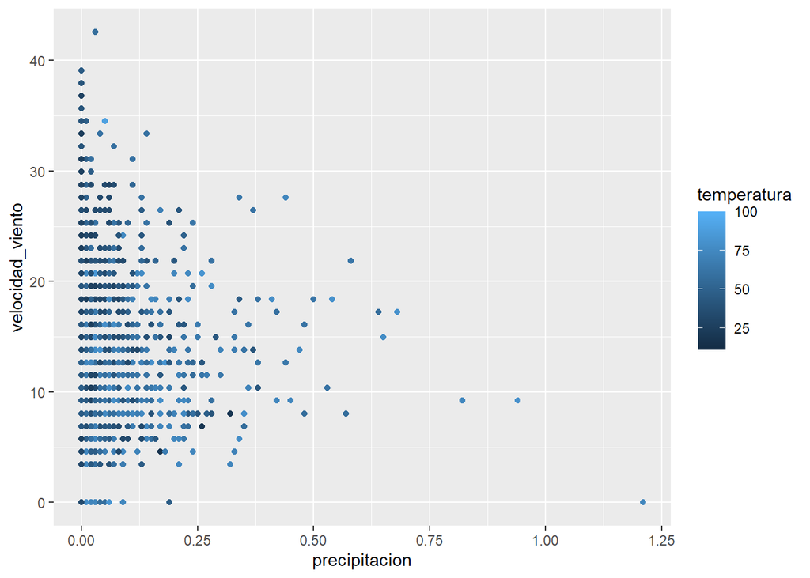

```r
ggplot(clima_peores_horas_salidas, aes(x = precipitacion, y = velocidad_viento, color = temperatura)) +
  geom_point()
```

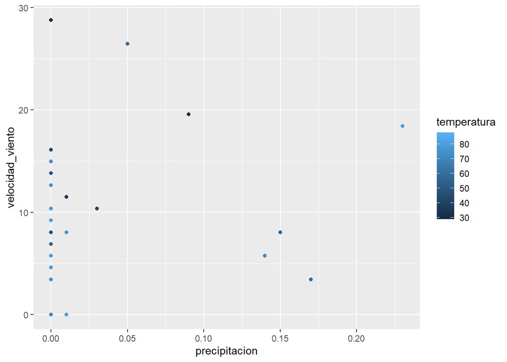

```r
ggplot(clima_peores_horas_llegadas, aes(x = precipitacion, y = velocidad_viento, color = temperatura)) +
  geom_point()
```

**5** ¿Qué te indica `anti_join(vuelos, aeropuertos, by = c("destino" = "codigo_aeropuerto"))`? ¿Qué te indica `anti_join(aeropuertos, vuelos, by = c("codigo_aeropuerto" = "destino"))`?

```r
ver1<-anti_join(vuelos, aeropuertos, by = c("destino" = "codigo_aeropuerto"))
ver1
```

```
## # A tibble: 7,602 x 19
##     anio   mes   dia horario_salida salida_programada atraso_salida
##    <int> <int> <int>          <int>             <int>         <dbl>
##  1  2013     1     1            544               545            -1
##  2  2013     1     1            615               615             0
##  3  2013     1     1            628               630            -2
##  4  2013     1     1            701               700             1
##  5  2013     1     1            711               715            -4
##  6  2013     1     1            820               820             0
##  7  2013     1     1            820               820             0
##  8  2013     1     1            840               845            -5
##  9  2013     1     1            909               810            59
## 10  2013     1     1            913               918            -5
## # ... with 7,592 more rows, and 13 more variables: horario_llegada <int>,
## #   llegada_programada <int>, atraso_llegada <dbl>, aerolinea <chr>,
## #   vuelo <int>, codigo_cola <chr>, origen <chr>, destino <chr>,
## #   tiempo_vuelo <dbl>, distancia <dbl>, hora <dbl>, minuto <dbl>,
## #   fecha_hora <dttm>
```

```r
ver2<-anti_join(aeropuertos, vuelos, by = c("codigo_aeropuerto" = "destino"))
ver2
```

```
## # A tibble: 1,357 x 8
##    codigo_aeropuerto nombre  latitud longitud altura zona_horaria horario_verano
##    <chr>             <chr>     <dbl>    <dbl>  <dbl>        <dbl> <chr>
##  1 04G               Lansdo~    41.1    -80.6   1044           -5 A
##  2 06A               Moton ~    32.5    -85.7    264           -6 A
##  3 06C               Schaum~    42.0    -88.1    801           -6 A
##  4 06N               Randal~    41.4    -74.4    523           -5 A
##  5 09J               Jekyll~    31.1    -81.4     11           -5 A
##  6 0A9               Elizab~    36.4    -82.2   1593           -5 A
##  7 0G6               Willia~    41.5    -84.5    730           -5 A
##  8 0G7               Finger~    42.9    -76.8    492           -5 A
##  9 0P2               Shoest~    39.8    -76.6   1000           -5 U
## 10 0S9               Jeffer~    48.1   -123.     108           -8 A
## # ... with 1,347 more rows, and 1 more variable: zona_horaria_iana <chr>
```

La primera expresión entrega los vuelos cuyo destino es un aeropuerto fuera de los EEUU.

La segunda expresión entrega lo aeropuertos de los EEUU que no son el destino de los vuelos contenidos en los datos.

Los datos contienen todos los vuelos de los aeropuertos de Nueva York, por lo que también contiene los vuelos con escalas intermedias.

**6** Puedes esperar que exista una relación implícita entre aviones y aerolíneas, dado que cada avión es operado por una única aerolínea. Confirma o descarta esta hipótesis usando las herramientas que aprendiste más arriba.

Veamos las combinaciones únicas de aerolínea y avión.

```r
aerolinea_avion <- vuelos %>%
  filter(!is.na(codigo_cola)) %>%
  distinct(aerolinea, codigo_cola)
```

Podría darse el caso en que una aerolínea vende algunos de sus aviones a otra. Estos aviones tendrán una cuenta mayor a uno en la tabla anterior.

```r
aerolinea_avion %>%
  count(codigo_cola) %>%
  filter(n > 1) %>%
  nrow()
```

```
## [1] 17
```

Veamos ahora las transferencias de aviones entre aerolíneas.

```r
aviones_transferidos <- aerolinea_avion %>%
  # conservo los aviones que han volado para más de una aerolínea
  group_by(codigo_cola) %>%
  filter(n() > 1) %>%
  # uno los códigos con los nombres de aerolínea
  left_join(aerolineas, by = "aerolinea") %>%
  arrange(aerolinea, codigo_cola)
aviones_transferidos
```

```
## # A tibble: 34 x 3
## # Groups:   codigo_cola [17]
##    aerolinea codigo_cola nombre
##    <chr>     <chr>       <chr>
##  1 9E        N146PQ      Endeavor Air Inc.
##  2 9E        N153PQ      Endeavor Air Inc.
##  3 9E        N176PQ      Endeavor Air Inc.
##  4 9E        N181PQ      Endeavor Air Inc.
##  5 9E        N197PQ      Endeavor Air Inc.
##  6 9E        N200PQ      Endeavor Air Inc.
##  7 9E        N228PQ      Endeavor Air Inc.
##  8 9E        N232PQ      Endeavor Air Inc.
##  9 DL        N933AT      Delta Air Lines Inc.
## 10 DL        N935AT      Delta Air Lines Inc.
## # ... with 24 more rows
```

# 4 Problemas con las uniones

Aquí se explica como sería una buena manera de limpiar los datos, ya que los datos usados en este capítulo están limpios. Tus datos difícilmente estarán tan ordenados, por lo que hay algunas consideraciones y pasos a tener en cuenta para que las uniones funcionen adecuadamente sobre tus propios datos.

**1** Comienza identificando las variables que forman las claves primarias en cada tabla. Usualmente debieras hacerlo considerando tus conocimientos de los datos, no observando empíricamente las combinaciones de variables que resultan en un identificador único. Si te centras en las variables sin pensar en sus significados, puedes tener la (mala) suerte de encontrar una combinación única en tus datos pero que no sea válida en general.

Por ejemplo, la altura y la longitud identifican de manera única cada aeropuerto, ¡pero no son buenos identificadores!

```r
aeropuertos %>% count(altura, longitud) %>% filter(n > 1)
```

```
## # A tibble: 0 x 3
## # ... with 3 variables: altura <dbl>, longitud <dbl>, n <int>
```

**2** Verifica que ninguna de las variables en la clave primaria esté perdida. ¡Si hay un valor faltante no podrá identificar una observación!

**3** Verifica que las claves foráneas coincidan con las claves primarias en otra tabla. La mejor forma de hacerlo es mediante un *anti_join()*. Es común que las claves no coincidan debido a errores en la entrada de datos. Arreglar este problema requiere mucho trabajo.

Si tienes claves perdidas, debes tener cuidado en el uso de unión interior versus unión exterior y considerar cuidadosamente si quieres descartar las filas que no tengan coincidencias.

Ten en cuenta que verificar el número de filas antes y después de unir no es suficiente para asegurar que la unión funcionó de forma exitosa. Si tienes una unión interior con claves duplicadas en ambas tablas, puedes tener la mala suerte de que el número de filas descartadas sea igual al número de filas duplicadas.

# 5 Operaciones de conjuntos

Si bien lo usamos de manera poco frecuente, en ocasiones es útil cuando quieres dividir un filtro complejo en partes maś simples. Todas estas operaciones funcionan con una fila completa, comparando los valores de cada variable. Esto espera que los input x e y tengan las mismas variables y trata las observaciones como conjuntos:

- *intersect(x, y):* devuelve las observaciones comunes en x e y.
- *union(x, y):* devuelve las observaciones únicas en x e y.
- *setdiff(x, y):* devuelve las observaciones en x pero no en y.

```r
df1 <- tribble(
  ~x, ~y,
  1, 1,
  2, 1
)
df2 <- tribble(
  ~x, ~y,
  1, 1,
  1, 2
)
```

```r
intersect(df1, df2)
```

```
## # A tibble: 1 x 2
##       x     y
##   <dbl> <dbl>
## 1     1     1
```

```r
union(df1, df2)
```

```
## # A tibble: 3 x 2
##       x     y
##   <dbl> <dbl>
## 1     1     1
## 2     2     1
## 3     1     2
```

```r
setdiff(df1, df2)
```

```
## # A tibble: 1 x 2
##       x     y
##   <dbl> <dbl>
## 1     2     1
```

```r
setdiff(df2, df1)
```

```
## # A tibble: 1 x 2
##       x     y
##   <dbl> <dbl>
## 1     1     2
```